## In-class worksheet 1

**Jan 22, 2019**

Much of the work in this class will be done via R Markdown documents. R Markdown documents are documents that combine text, R code, and R output, including figures. They are a great way to produce self-contained and documented statistical analyses.

In this first worksheet, you will learn how to do some basic markdown editing. After you have made a change to the document, press “Knit HTML” in R Studio and see what kind of a result you get.

Edit only below this line.

## 1. Basic Markdown editing

Try out basic R Markdown features, as described [here.](http://rmarkdown.rstudio.com/authoring_basics.html) Write some text that is bold, and some that is in italics. Make a numbered list and a bulleted list. Make a nested list. Try the block-quote feature.

For bold text.

**bold**

For italic.

*italic*

For numbered lists.

1. item1
2. item2

For bulleted list

- item3
- item4

For nested list

1. item5
2. item6
   - item7
   - item8

For block-quote feature

> Hi, this is Akshay I am trying block-quote feature

## 2. Embedding R code

For headers use the above code. R code embedded in R chunks will be executed and the output will be shown.

```r
# R code goes here
x <- 5
y <- 7
z <- x * y
z
```

```
## [1] 35
```

Play around with some basic R code. E.g., take the built-in data set `cars`, which lists speed and stopping distance for cars from the 1920. Plot speed vs. distance, and/or perform a correlation analysis. Then write a few sentences describing what you see.

```r
head(cars)
```

```
##   speed dist
## 1     4    2
## 2     4   10
## 3     7    4
## 4     7   22
## 5     8   16
## 6     9   10
```

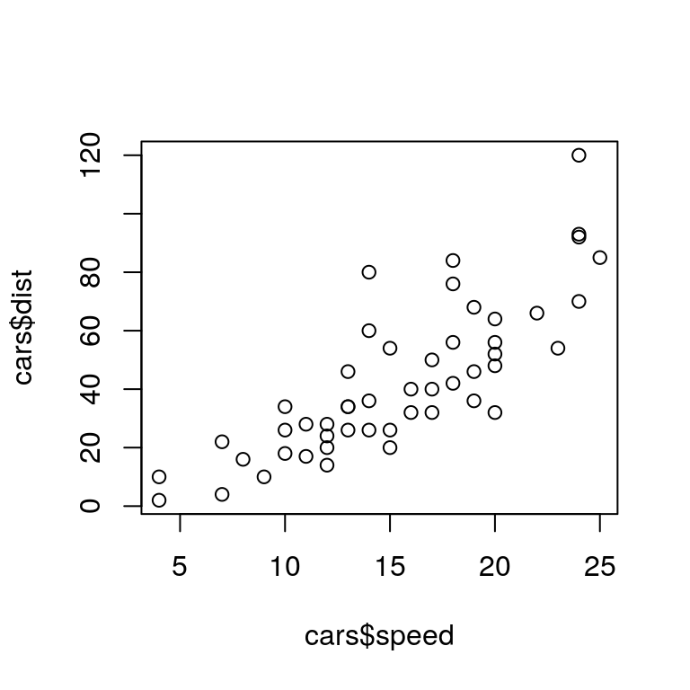

```r
plot(cars$speed,cars$dist)
```

```r
cor(cars$speed,cars$dist)
```

```
## [1] 0.8068949
```

Seeing the plot and correlation value, it looks like the variables are highly correlated.

## 3. If this was easy

If this was easy, use Google to find out how to type-set mathematical formulas inside of R markdown.

This summation expression $\sum_{i=1}^n X_i$ appears inline.

This summation expression is in display form.

$$\sum_{i=1}^n X_i$$
http://www.statpower.net/Content/310/R%20Stuff/SampleMarkdown.html